# Introduction to Jupyter Notebook

Programming Capability SIT

Tao Dong

July 25, 2016

## 1. What is [Jupiter notebook](http://jupyter.org)

> The Jupiter Notebook is a web-based interactive computational environment where you can combine code execution, text, mathematics, plots and rich media into a single document. These notebooks are normal files that can be shared with colleagues, converted to other formats such as HTML or PDF, etc. This makes it easy to give your colleagues a document they can read immediately without having to install anything.

**Previous known as IPython Notebook:** "I" for "Interactive".  
**Try in your browser:** https://try.jupyter.org

**Install:** Python is a requirement, recommand [Anaconda](https://www.continuum.io/downloads). The Anaconda Python distribution comes with many scientific computing and data science packages and is free, including for commercial use and redistribution. For installation guid, see [here](https://jupyter.readthedocs.io/en/latest/install.html).

## 2. Notebook Basics

- Starting the notebook server
- Notebook Dashboard and Editor
- Creating a new notebook document
- Kernels [other kernels](https://github.com/ipython/ipython/wiki/IPython%20kernels%20for%20other%20languages)
- Renaming a notebook
- Shutdown a notebook
- Exporting a notebook

## 3. Running code

The keyboard shortcuts to run code: Shift-Enter

```python
1 + 2
```

```
3
```

```python
a = 10
```

```python
print a
```

```
10
```

```python
b = [1,3,5]
print b
```

```
[1, 3, 5]
```

```python
print 'Hello World!'
```

```
Hello World!
```

```python
for i in range(50):
    print(i)
```

```
0
1
2
3
4
5
6
7
8
9
10
11
12
13
14
15
16
17
18
19
20
21
22
23
24
25
26
27
28
29
30
31
32
33
34
35
36
37
38
39
40
41
42
43
44
45
46
47
48
49
```

#### Explore the Cell menu :

Run/Run All/Run All Above/Run All Below  
Here is another line of documentation

**Restart the kernel**  
The kernel maintains the state of a notebook's computations. You can reset this state by restarting the kernel.

## 4. Rich format display

```python
from IPython.display import Image
Image(url='http://python.org/images/python-logo.gif')
```

```python
from IPython.display import Audio
Audio(url="http://www.nch.com.au/acm/8k16bitpcm.wav")
```

[interactive chart not shown]

```python
from IPython.display import YouTubeVideo
YouTubeVideo('MQ3k6BFX2uw')
```

[video not shown]

```python
from IPython.display import Math
Math(r'F(k) = \int_{-\infty}^{\infty} f(x) e^{2\pi i k} dx')
```

$$F(k) = \int_{-\infty}^{\infty} f(x) e^{2\pi i k} dx$$

#### Direct type of expressions:

\begin{eqnarray} \nabla \times \vec{\mathbf{B}} -\, \frac1c\, \frac{\partial\vec{\mathbf{E}}}{\partial t} & = \frac{4\pi}{c}\vec{\mathbf{j}} \\ \nabla \cdot \vec{\mathbf{E}} & = 4 \pi \rho \\ \nabla \times \vec{\mathbf{E}}\, +\, \frac1c\, \frac{\partial\vec{\mathbf{B}}}{\partial t} & = \vec{\mathbf{0}} \\ \nabla \cdot \vec{\mathbf{B}} & = 0 \end{eqnarray}

## 5. Cell magics

Timing the execution of code; the 'timeit' magic exists both in line and cell form:

```python
import numpy as np
%timeit np.linalg.eigvals(np.random.rand(100,100))
```

```
The slowest run took 23.39 times longer than the fastest. This could mean that an intermediate result is being cached
100 loops, best of 3: 3.86 ms per loop
```

The %%writefile magic is a very useful tool that writes the cell contents as a named file:

```python
%%writefile foo.py
print 'Hello world!'
```

```
Overwriting foo.py
```

```python
%run foo
```

```
Hello world!
```

## 6. A simple classification example - Iris

[figure not shown]

```python
from sklearn import datasets
import pandas as pd
iris = datasets.load_iris()
X = pd.DataFrame(iris.data)
Y = pd.DataFrame(iris.target)
```

```python
iris_data = pd.concat([X,Y], axis=1)
iris_data.columns = iris.feature_names + ['class']
```

```python
iris_data.head()
```

|  | sepal length (cm) | sepal width (cm) | petal length (cm) | petal width (cm) | class |
| --- | --- | --- | --- | --- | --- |
| 0 | 5.1 | 3.5 | 1.4 | 0.2 | 0 |
| 1 | 4.9 | 3.0 | 1.4 | 0.2 | 0 |
| 2 | 4.7 | 3.2 | 1.3 | 0.2 | 0 |
| 3 | 4.6 | 3.1 | 1.5 | 0.2 | 0 |
| 4 | 5.0 | 3.6 | 1.4 | 0.2 | 0 |

```python
iris_data.describe()
```

|  | sepal length (cm) | sepal width (cm) | petal length (cm) | petal width (cm) | class |
| --- | --- | --- | --- | --- | --- |
| count | 150.000000 | 150.000000 | 150.000000 | 150.000000 | 150.000000 |
| mean | 5.843333 | 3.054000 | 3.758667 | 1.198667 | 1.000000 |
| std | 0.828066 | 0.433594 | 1.764420 | 0.763161 | 0.819232 |
| min | 4.300000 | 2.000000 | 1.000000 | 0.100000 | 0.000000 |
| 25% | 5.100000 | 2.800000 | 1.600000 | 0.300000 | 0.000000 |
| 50% | 5.800000 | 3.000000 | 4.350000 | 1.300000 | 1.000000 |
| 75% | 6.400000 | 3.300000 | 5.100000 | 1.800000 | 2.000000 |
| max | 7.900000 | 4.400000 | 6.900000 | 2.500000 | 2.000000 |

**Plotting within notebook**

```python
# This line tells the notebook to show plots inside of the notebook
%matplotlib inline

# This is to import libraries for plotting, you may need to install those packages before run
import matplotlib.pyplot as plt
import seaborn as sb
```

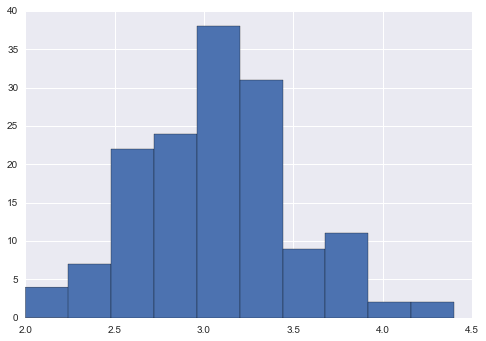

```python
iris_data['sepal width (cm)'].hist()
```

Let's create a **scatterplot matrix**. Scatterplot matrices plot the distribution of each column along the diagonal, and then plot a scatterplot matrix for the combination of each variable. They make for an efficient tool to look for errors in our data.

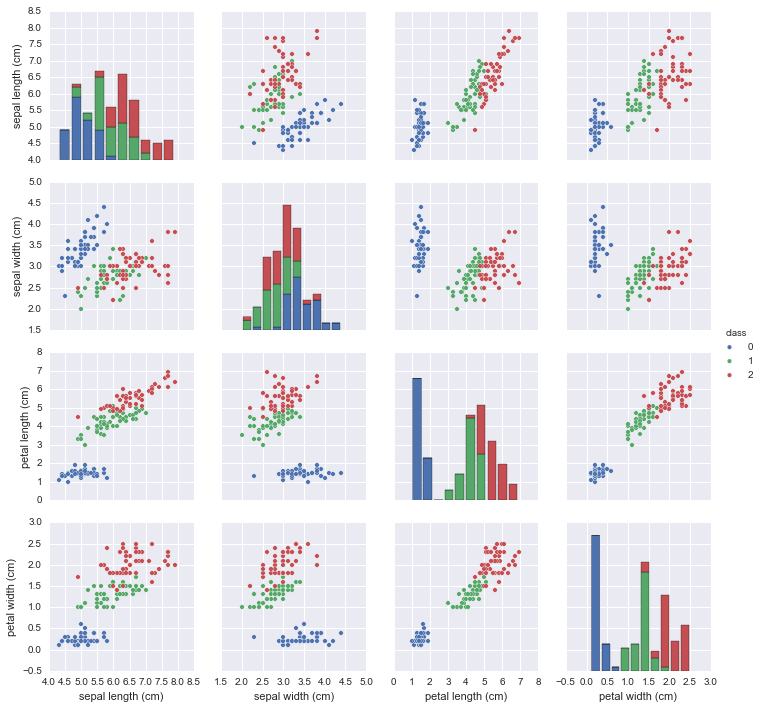

```python
# We have to temporarily drop the rows with 'NA' values
# because the Seaborn plotting function does not know
# what to do with them
sb.pairplot(iris_data, hue='class', vars=iris.feature_names)
```

We can also make **violin plots** of the data to compare the measurement distributions of the classes. Violin plots contain the same information as box plots, but also scales the box according to the density of the data.

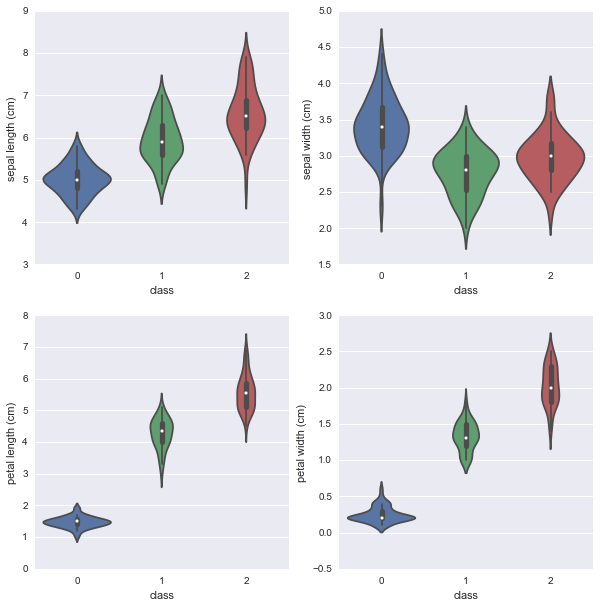

```python
plt.figure(figsize=(10, 10))

for column_index, column in enumerate(iris.feature_names):
#     if column == 'class':
#         continue
    plt.subplot(2, 2, column_index + 1)
    sb.violinplot(x='class', y=column, data=iris_data)
```

It's time to **model** our data to do some **classification**.

The first step is to split the data into training and testing sets. A training set is a random subset of the data that we use to train our models. A testing set is a random subset of the data (mutually exclusive from the training set) that we use to validate our models on unforseen data.

```python
from sklearn.cross_validation import train_test_split

(training_inputs,
 testing_inputs,
 training_classes,
 testing_classes) = train_test_split(X, Y, train_size=0.75, random_state=1)
```

Let's try a basic decision tree model

```python
from sklearn.tree import DecisionTreeClassifier

# Create the classifier
decision_tree_classifier = DecisionTreeClassifier()

# Train the classifier on the training set
decision_tree_classifier.fit(training_inputs, training_classes)

# Validate the classifier on the testing set using classification accuracy
decision_tree_classifier.score(testing_inputs, testing_classes)
```

```
0.97368421052631582
```

We can even visualize the decision tree with GraphViz to see how it's making the classifications:

```python
import sklearn.tree as tree
from sklearn.externals.six import StringIO

with open('iris_dtc.dot', 'w') as out_file:
    out_file = tree.export_graphviz(decision_tree_classifier, out_file=out_file)
```

```python
# Run bash command from inside Jupyter notebook
!dot -Tsvg iris_dtc.dot -o tree.svg
```

[figure not shown]